$$GAM : Prevalence = b_0 + s(Dist_{Port}|Lineage) + s(Fetch|Lineage) +
s(PC1|Lineage) +s(OGP|Lineage) + Lineage + \varepsilon$$

Параметры GAM

| Член модели | edf | ref.df | Chi.sq Statistic | p.value |
| --- | --- | --- | --- | --- |
| s(Dist_Port):LineageBTN1 | 1.0 | 1.0 | 9.2 | 0.002 |
| s(Dist_Port):LineageBTN2 | 1.0 | 1.0 | 3.4 | 0.065 |
| s(fetch):LineageBTN1 | 1.0 | 1.0 | 9.3 | 0.002 |
| s(fetch):LineageBTN2 | 1.0 | 1.0 | 0.0 | 0.979 |
| s(PC1):LineageBTN1 | 2.0 | 2.3 | 8.3 | 0.016 |
| s(PC1):LineageBTN2 | 1.7 | 2.1 | 5.5 | 0.072 |
| s(OGP):LineageBTN1 | 1.7 | 1.9 | 6.0 | 0.048 |
| s(OGP):LineageBTN2 | 1.0 | 1.0 | 2.6 | 0.105 |

## **Предсказание модели**

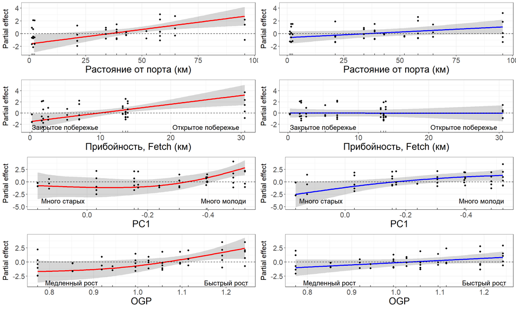

Зависимость от изученных внешних факторов у BTN2 выражена слабо. У BTN1 связи более сильные. Это можно трактовать, как более выраженную стенобионтность линии BTN1. BTN2 - более эврибионтная линия.

# Влияние BTN на хозяина

## Зависимость частоты нарушения развития гонад от степени развития заболевания

Параметры GAM

| Член модели | edf | ref.df | Chi.sq Statistic | p.value |
| --- | --- | --- | --- | --- |
| s(Aneuploid_Proportion):LineageBTN1 | 1.0 | 1.0 | 10.3 | 0.001 |
| s(Aneuploid_Proportion):LineageBTN2 | 1.0 | 1.0 | 2.0 | 0.153 |

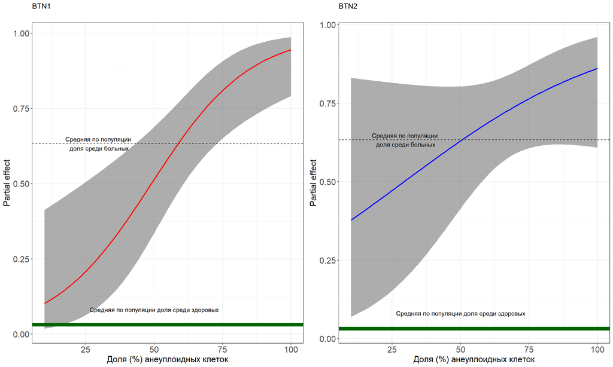

При заражении MtrBTN1 видимые нарушения наступают на более поздних стадиях заболевания, при заражении MtrBTN2 видимые нарушения наступают раньше, уже начиная с ранних стадий заболевания

## Влияние BTN на рост моллюсков

$$GAM: \varphi = s(L_{LastRing}|Status) + Status$$

Здесь $\varphi$ - относительный прирост последнего года (отношение размера последнего кольца к общей длине раковины, после $\varphi$-преобразования Фишера); $(L_{LastRing}$ - расстояние от вершины раковины до последнего кольца остановки роста, ковариата оценивающая размер моллюска; $Status$ - фактор с тремя градациями: Здоровые, Зараженные BTN1, Зараженные BTN2. Модель основана на нормальном распределении.

$s(L_{LastRing}|Status)$

| Член модели | estimate | std.error | F | p.value |
| --- | --- | --- | --- | --- |
| (Intercept) | 25.08 | 1.22 | 20.51 | 0.0000 |
| BTN_TypeBTN2 | 4.24 | 1.66 | 2.55 | 0.0109 |
| BTN_TypeЗдоровые | 0.67 | 1.07 | 0.63 | 0.5307 |

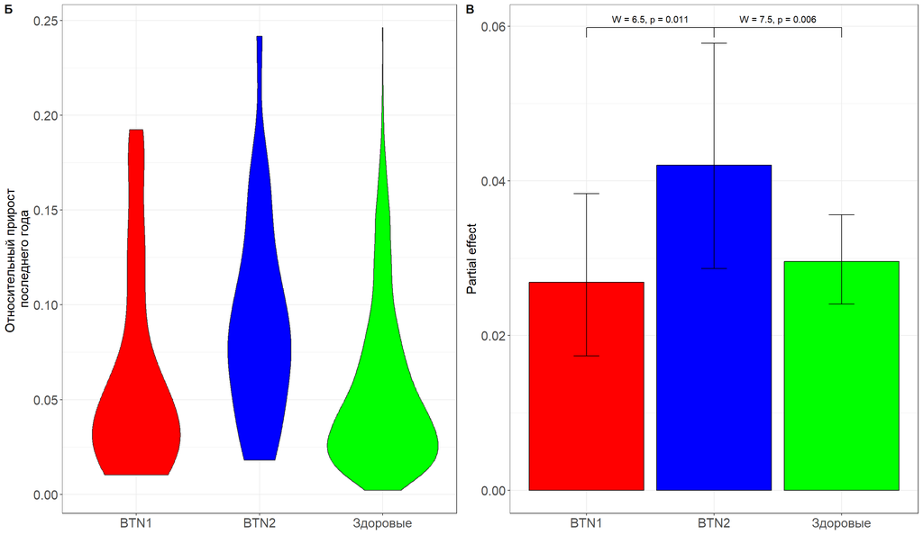

Прирост последнего года у зараженных BTN2 оказывается выше, чем у зараженных $MtrBTN1$ и у здоровых особей, которые между собой не отличаются.

**Разные стратегии у BTN1 и BTN2** (это основные обобщающие положения, которые можно использовать для текста)

- Паразиты живут в мире с двумя экологическими осями: ресурсы хозяина (*среда I прядка*) и внешние факторы (*среда II порядка*). Положение экологической ниши в этих осях определяет успех паразита.
- В отличие от $MtrBTN1$, $MtrBTN2$ стимулирует соматический рост хозяина за счет эффективного подавления его репродукции. Это может быть уподоблено паразитарной кастрации. $MtrBTN2$ более эффективно использует ресурсы среды I порядка.
- В отличие от $MtrBTN2$, $MtrBTN1$ сильно зависит от факторов среды II порядка. Возможно это является следствием менее эффективного использования ресурсов среды I порядка.
- С разной стратегией двух линий $BTN$ могут быть связаны особенности их географического распространения: более узкое (субарктика) у $MtrBTN1$ и более широкое (практически всесветное) у $MtrBTN2$